# Proj2_BoneMed

### Clustering.

```r
#remove the response so it is truly unsupervised
#boneTrainX <- boneTrain_pc1 %>% dplyr::select(-"Fracture")
#boneTrainY <- boneTrain_pc1 %>% dplyr::select("Fracture")
#str(boneTrainX)
```

- K-Means and Hierarchical clustering use Euclidean or Manhattan distance which are only suitable for continuous variables variables and NOT categorical variables.
- Gower distance

```r
library(cluster)
#exclude Fracture column
#Calculating the gower distance.
#Note that gower distance is
as.data.frame(colnames(boneTrain_pc1))
```

```
##   colnames(boneTrain_pc1)
## 1               fracscore
## 2                 bonemed
## 3              bonemed_fu
## 4               bonetreat
## 5                     PC1
## 6                     PC2
## 7                Fracture
```

```r
gower_df <- daisy(boneTrain_pc1[,-12], metric = "gower")
summary(gower_df)
```

```
## 79800 dissimilarities, summarized :
##    Min. 1st Qu.  Median    Mean 3rd Qu.    Max.
## 0.00000 0.09097 0.23262 0.30050 0.50167 0.84306
## Metric :  mixed ;  Types = I, N, N, N, I, I, N
## Number of objects : 400
```

- k-Means is sensitive to outliers which can significantly distort the mean value of the cluster.

Instead of taking the mean value of the objects in a cluster as a reference point, we can pick actual objects (i.e. observation) to represent the clusters, using one representative object per cluster. Each remaining object is assigned to the cluster of which the representative object is the most similar. The partitioning method is then performed based on the principle of minimizing the sum of the dissimilarities between each object p and its corresponding representative object. Partitioning Around Medoids (PAM) algorithm is a realization of k-medoids clustering. Partitioning around medoids is an iterative clustering procedure with the following steps: 1. Choose k random entities to become the medoids 2. Assign every entity to its closest medoid (using our custom distance matrix in this case) 3. For each cluster, identify the observation that would yield the lowest average distance if it were to be re-assigned as the medoid. If so, make this observation the new medoid. 4. If at least one medoid has changed, return to step 2. Otherwise, end the algorithm.

*Silhouette width is the most popular metric used to select the number of k.It is an internal validation metric which is an aggregated measure of how similar an observation is to its own cluster compared its closest neighboring cluster.

- choose a clustering algorithm to infer similarities/dissimilarities from the calculated distances.
- Partitioning Around Medoids (PAM) algorithm goes along with the Gower distance.
- PAM is an iterative clustering procedure. Instead of centroids in K-means clustering, PAM iterates over and over until the medoids don’t change their positions. The medoid of a cluster is a member of the cluster which is representative of the median of all the attributes under consideration.

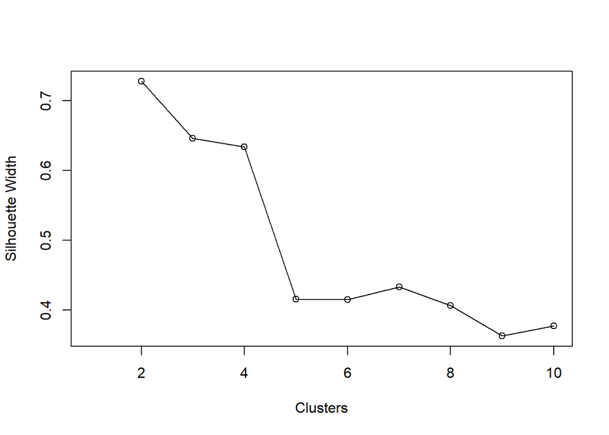

```r
# Calculate silhouette width for many k using PAM
silhouette <- c()
silhouette = c(silhouette, NA)
for(i in 2:10){
  pam_clusters = pam(as.matrix(gower_df),
                 diss = TRUE,
                 k = i)
  silhouette = c(silhouette ,pam_clusters$silinfo$avg.width)
}



# Plot sihouette width (higher is better)
plot(1:10, silhouette,
     xlab = "Clusters",
     ylab = "Silhouette Width")
lines(1:10, silhouette)
```

Let us view the clusters to select the optimal number based on how much separation e can see in 2D space.

use the set.seed

```r
library(Rtsne)
```

```r
library(ggplot2)
set.seed(123)
tsne_object <- Rtsne(gower_df, is_distance = TRUE)
tsne_df <- tsne_object$Y %>%
  data.frame() %>%
  setNames(c("X", "Y")) %>%
  mutate(cluster = factor(pam_fit$clustering))
```

[output not shown]

```r
ggplot(aes(x = X, y = Y), data = tsne_df) +
  geom_point(aes(color = cluster))
```

[output not shown]

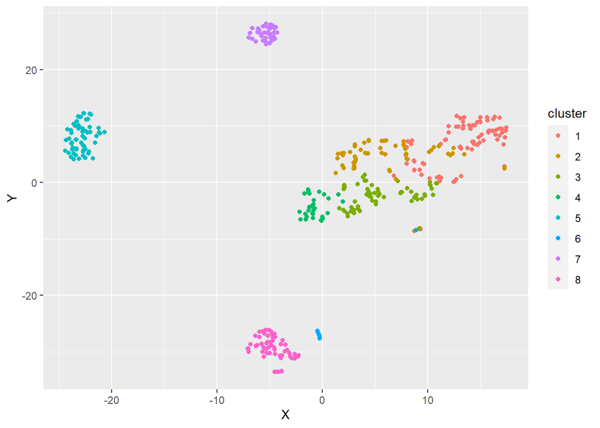

```r
set.seed(123)
pam_fit8 <- pam(gower_df, diss = TRUE, k=8)
tsne_object <- Rtsne(gower_df, is_distance = TRUE)
tsne_df <- tsne_object$Y %>%
  data.frame() %>%
  setNames(c("X", "Y")) %>%
  mutate(cluster = factor(pam_fit8$clustering))
ggplot(aes(x = X, y = Y), data = tsne_df) +
  geom_point(aes(color = cluster))
```

RANGE OF Silhouette clusters https://web.archive.org/web/20111002220803/http://www.unesco.org:80/webworld/idams/advguide/Chapt7_1_1.htm

INTERPRETATION

0.71-1.0 A strong structure has been found

0.51-0.70 A reasonable structure has been found

0.26-0.50 The structure is weak and could be artificial. Try additional methods of data analysis.

<= 0.25 No substantial structure has been found

We can fit each cluster onto the dataset to view what they look like for k = 2. Summary of each cluster

```r
k <- 2
pam_fit <- pam(gower_df, diss = TRUE, k)
pam_results.group <- boneTrain_pc1 %>%
  dplyr::select(-Fracture) %>%
  mutate(cluster = pam_fit$clustering) %>%
  group_by(cluster) %>%
  do(the_summary = summary(.))

pam_results.group$the_summary
```

```
## [[1]]
##    fracscore      bonemed   bonemed_fu bonetreat      PC1
##  Min.   : 0.000   No :295   No :289    No :305   Min.   :-4.7346
##  1st Qu.: 1.000   Yes: 10   Yes: 16    Yes:  0   1st Qu.:-1.2396
##  Median : 3.000                                  Median :-0.0422
##  Mean   : 3.384                                  Mean   :-0.2576
##  3rd Qu.: 5.000                                  3rd Qu.: 0.8027
##  Max.   :11.000                                  Max.   : 2.4724
##       PC2              cluster
##  Min.   :-2.65605   Min.   :1
##  1st Qu.:-0.59882   1st Qu.:1
##  Median : 0.06372   Median :1
##  Mean   : 0.05913   Mean   :1
##  3rd Qu.: 0.71985   3rd Qu.:1
##  Max.   : 5.78869   Max.   :1
##
## [[2]]
##    fracscore      bonemed  bonemed_fu bonetreat      PC1
##  Min.   : 0.000   No : 0   No : 0     No : 0    Min.   :-3.6962
##  1st Qu.: 2.000   Yes:95   Yes:95     Yes:95    1st Qu.: 0.2141
##  Median : 5.000                                 Median : 0.9368
##  Mean   : 4.495                                 Mean   : 0.8271
##  3rd Qu.: 6.000                                 3rd Qu.: 1.6360
##  Max.   :10.000                                 Max.   : 3.0779
##       PC2             cluster
##  Min.   :-4.7426   Min.   :2
##  1st Qu.:-0.9185   1st Qu.:2
##  Median :-0.1484   Median :2
##  Mean   :-0.1898   Mean   :2
##  3rd Qu.: 0.6366   3rd Qu.:2
##  Max.   : 2.8962   Max.   :2
```

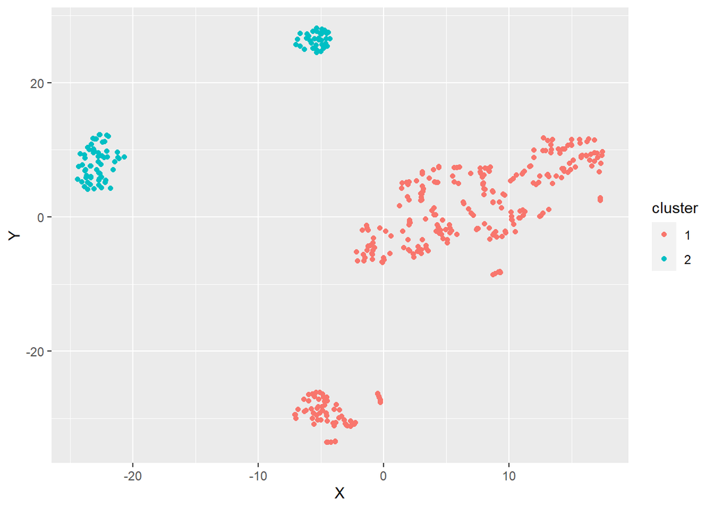

```r
set.seed(123)
pam_fit <- pam(gower_df, diss = TRUE, k=2)
tsne_object <- Rtsne(gower_df, is_distance = TRUE)
tsne_df <- tsne_object$Y %>%
  data.frame() %>%
  setNames(c("X", "Y")) %>%
  mutate(cluster = factor(pam_fit$clustering))
ggplot(aes(x = X, y = Y), data = tsne_df) +
  geom_point(aes(color = cluster))
```

Typical values of members belonging to each cluster

```r
boneTrain_pc1[pam_fit$medoids, ]
```

```
##     fracscore bonemed bonemed_fu bonetreat        PC1         PC2 Fracture
## 187         3      No         No        No 0.05097017  0.03245309       No
## 57          5     Yes        Yes       Yes 0.75566498 -0.34317704       No
```

Results of clusters are added as new attributes with each observation assigned its cluster number and Fracture response placed as last attribute. Adding response to cluster results

```r
pam_results <- boneTrain_pc1 %>%
  mutate(cluster = pam_fit$clustering)


pam_results["Fracture1"] = boneTrain_pc1$Fracture
pam_results = subset(pam_results, select=-c(Fracture))
pam_results$cluster <- factor(pam_results$cluster)
str(pam_results)
```

```
## 'data.frame':    400 obs. of  8 variables:
##  $ fracscore : int  1 2 5 1 6 7 0 4 3 1 ...
##  $ bonemed   : Factor w/ 2 levels "No","Yes": 1 1 1 1 1 1 1 1 1 1 ...
##  $ bonemed_fu: Factor w/ 2 levels "No","Yes": 1 1 1 1 1 1 1 1 1 1 ...
##  $ bonetreat : Factor w/ 2 levels "No","Yes": 1 1 1 1 1 1 1 1 1 1 ...
##  $ PC1       : num  -0.0986 -1.3436 1.3123 0.0604 2.4081 ...
##  $ PC2       : num  -0.104 -0.576 -0.565 -0.839 -1.651 ...
##  $ cluster   : Factor w/ 2 levels "1","2": 1 1 1 1 1 1 1 1 1 1 ...
##  $ Fracture1 : Factor w/ 2 levels "No","Yes": 1 1 1 1 1 1 1 1 1 1 ...
```